# Supervised Learning

# Overview of Supervised Learning

## General overview

Supervised learning is a type of machine learning that aims to fit the best model for predicting values of a labeled variable. The purpose of performing supervised learning to this data is to gain insight into how strong internal connections are between data points and variables, and if they have strength in being used to estimate another variable’s value. Three types of supervised learning will be performed in different sections: Binary classification, Multi-class classification, and Regression. The model selection methods, evaluation metrics, and results will be discussed within each of those sections.

Below is an outline of general information applied to all models:

### Data preprocessing

In order to be used in supervised learning, data has to be cleaned, processed and standardized following specific criteria in order to be appropriately used. The following techniques have been performed on the data for use in the models throughout this section:

*Handling categorical variables* - Categorical variables (Subregion and prostitution policy) were **one-hot encoded** in order to be represented as numerical variables and included in the supervised learning models

[output not shown]

*Standardization* - The data was scaled using Sci-kit learn’s StandardScaler, a python package tool that automatically applies z-score standardization to the data, which reduces all data points to a more standard and comparable metric

### Testing and training strategy

```python
import pandas as pd
import numpy as np
from sklearn.model_selection import train_test_split
from sklearn.ensemble import RandomForestClassifier
from sklearn.metrics import classification_report, confusion_matrix
from sklearn.preprocessing import StandardScaler
import matplotlib.pyplot as plt
import seaborn as sns
```

```python
df = pd.read_csv('../../data/processed-data/MLdataset.csv')
df.columns
```

```
Index(['Country', 'Detected_victims_sum', 'Detected_victims_slope',
       'Convicted_traffickers_sum', 'Convicted_traffickers_slope',
       'Prosecuted_traffickers_sum', 'Prosecuted_traffickers_slope',
       'Convictions_over_prosecutions_mean', 'Number_Repatriated_Victims_sum',
       'Tier_mean', 'Tier_slope', 'Criminal_justice_mean',
       'Criminal_justice_slope', 'GDP_per_capita_mean', 'GDP_per_capita_slope',
       'Political_stability_mean', 'Political_stability_slope',
       'Population_mean', 'Refugee_population_mean',
       'Refugee_population_slope', 'Unemployment_rate_mean',
       'Unemployment_rate_slope', 'Detections_per_100_mean',
       'Reported_Years_Detected_Victims', 'Subregion',
       'Nonpunishment_policy_before2021', 'Nonpunishment_policy_after2021',
       'Limited_nonpunishment_policy', 'Post_soviet_states', 'EU_members',
       'Tier_2024', 'Visa_free_destinations', 'GSI_gov_response_score',
       'prostitution_policy'],
      dtype='object')
```

```python
df.dtypes
```

```
Country                                object
Detected_victims_sum                  float64
Detected_victims_slope                float64
Convicted_traffickers_sum             float64
Convicted_traffickers_slope           float64
Prosecuted_traffickers_sum            float64
Prosecuted_traffickers_slope          float64
Convictions_over_prosecutions_mean    float64
Number_Repatriated_Victims_sum        float64
Tier_mean                             float64
Tier_slope                            float64
Criminal_justice_mean                 float64
Criminal_justice_slope                float64
GDP_per_capita_mean                   float64
GDP_per_capita_slope                  float64
Political_stability_mean              float64
Political_stability_slope             float64
Population_mean                       float64
Refugee_population_mean               float64
Refugee_population_slope              float64
Unemployment_rate_mean                float64
Unemployment_rate_slope               float64
Detections_per_100_mean               float64
Reported_Years_Detected_Victims         int64
Subregion                              object
Nonpunishment_policy_before2021       float64
Nonpunishment_policy_after2021        float64
Limited_nonpunishment_policy          float64
Post_soviet_states                    float64
EU_members                            float64
Tier_2024                             float64
Visa_free_destinations                float64
GSI_gov_response_score                float64
prostitution_policy                    object
dtype: object
```

# Binary Classification

In this section, I model the important features for predicting whether or not a country has passed legislation specifying victim non-punishment policy. I will train, evaluate, and compare the following models:

### Model selection:

- **Logistic Regression**: method that classifies binary variables by predicting the likelihood that a given input corresponds to one of two predefined categories using information from the other features in the data
  - Uses a sigmoid function to map input features to binary outcomes (0 or 1)
  - *Inclusion justification*: This method was chosen because is one of the most fundamental methods for binary classification due to its simplicity, interpretability, and high performance on linearly separable data
- **Random Forest**: ensemble method that builds multiple decision trees and combines their predictions through averaging and selecting the best performance vote
  - Each tree is trained on a random subset of data and features, reducing overfitting and improving generalization
  - *Inclusion justification*: It is one of those most common and fundamental supervised learning algorithms and has many strengths, including flexibility, the reduction of overfitting and accuracy through bagging results (calculating the aggregate across bootstrap samples)
- **Naive Bayes**: method that makes a *“naive”* assumption of feature independenceuses and uses *Bayes’* theorem to predict class membership probabilities
  - *Inclusion justification*: This method is known to work well on small training sets and high-dimensional and complex data, which characterizes the data used for this project.

### Evaluation metrics:

The following evaluation metrics were calculated for each model and compared: - Accuracy - Precision - Recall - F1 score - ROC-AUC

```
Model Performance Metrics for predicting Nonpunishment_policy_after2021:
              Model  Accuracy  Precision  Recall  F1 Score  ROC-AUC
Logistic Regression       0.7   0.750000     0.6  0.666667     0.88
      Random Forest       0.8   0.800000     0.8  0.800000     0.96
        Naive Bayes       0.8   0.714286     1.0  0.833333     0.92
```

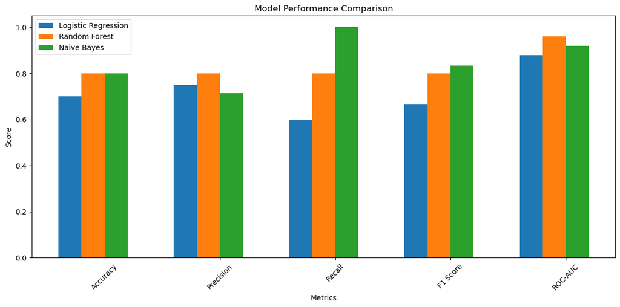

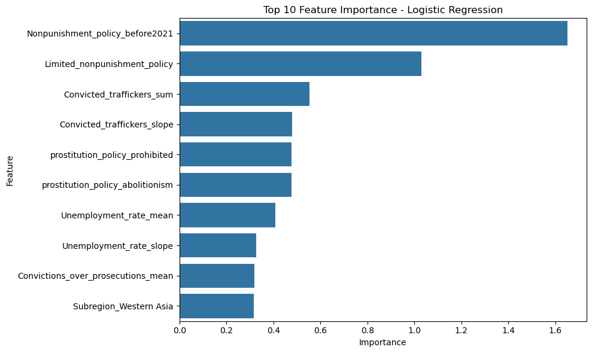

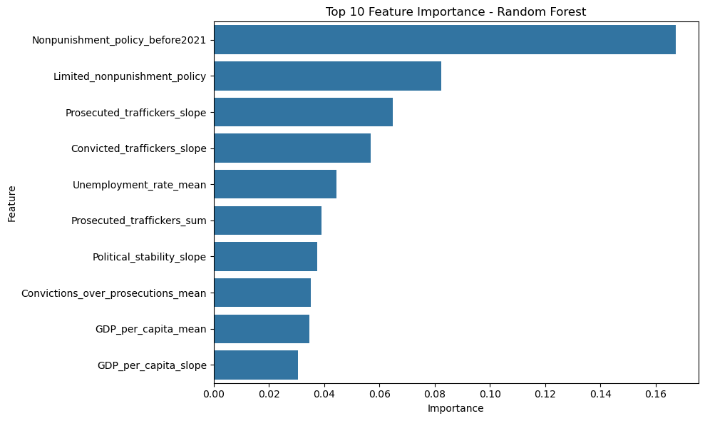

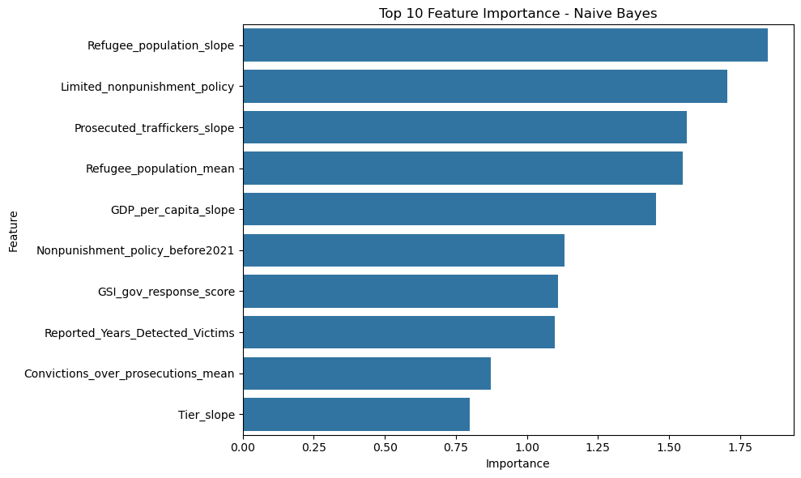

```python
import pandas as pd
import numpy as np
from sklearn.preprocessing import LabelEncoder, StandardScaler
from sklearn.model_selection import train_test_split
from sklearn.linear_model import LogisticRegression
from sklearn.ensemble import RandomForestClassifier
from sklearn.neighbors import KNeighborsClassifier
from sklearn.naive_bayes import GaussianNB
from sklearn.metrics import accuracy_score, precision_score, recall_score, f1_score, roc_auc_score
from sklearn.impute import SimpleImputer
import matplotlib.pyplot as plt
import seaborn as sns

# prepare data by one hot encoding categorical variables
def prepare_data_with_categorical(df, target_variable):
    # dummy variables
    categorical_columns = ['Subregion', 'prostitution_policy']
    dummy_dfs = []

    for col in categorical_columns:
        if col in df.columns:
            dummy_df = pd.get_dummies(df[col], prefix=col)
            dummy_dfs.append(dummy_df)

    # Combine numerical and dummy variables
    numerical_df = df.select_dtypes(include=['float64', 'int64'])
    X = pd.concat([numerical_df] + dummy_dfs, axis=1)

    columns_to_drop = [target_variable, 'Country']
    X = X.drop([col for col in columns_to_drop if col in X.columns], axis=1)

    # Handle NAs
    imputer = SimpleImputer(strategy='median')
    X = pd.DataFrame(imputer.fit_transform(X), columns=X.columns)

    # Standardize
    numerical_cols = numerical_df.columns
    numerical_cols = [col for col in numerical_cols if col in X.columns]
    scaler = StandardScaler()
    X[numerical_cols] = scaler.fit_transform(X[numerical_cols])

    return X, numerical_cols

def train_and_evaluate_models(X_train, X_test, y_train, y_test):
    # Initialize models
    models = {
        'Logistic Regression': LogisticRegression(random_state=6547),
        'Random Forest': RandomForestClassifier(random_state=6547),
        'Naive Bayes': GaussianNB()
    }

    results = []
    feature_importances = {}

    for name, model in models.items():
        # Train
        model.fit(X_train, y_train)

        # Predict
        y_pred = model.predict(X_test)
        y_pred_proba = model.predict_proba(X_test)[:, 1]

        # evaluation metrics
        metrics = {
            'Model': name,
            'Accuracy': accuracy_score(y_test, y_pred),
            'Precision': precision_score(y_test, y_pred),
            'Recall': recall_score(y_test, y_pred),
            'F1 Score': f1_score(y_test, y_pred),
            'ROC-AUC': roc_auc_score(y_test, y_pred_proba)
        }
        results.append(metrics)

        # feature importance
        if name == 'Logistic Regression':
            importance = np.abs(model.coef_[0])
        elif name == 'Random Forest':
            importance = model.feature_importances_
        elif name == 'Naive Bayes':
            importance = np.abs(model.var_[0] - model.var_[1])
        elif name == 'k-NN':
            from sklearn.feature_selection import mutual_info_classif
            importance = mutual_info_classif(X_train, y_train)

        feature_importances[name] = importance

    return pd.DataFrame(results), feature_importances

def plot_model_comparison(results):
    metrics = ['Accuracy', 'Precision', 'Recall', 'F1 Score', 'ROC-AUC']

    plt.figure(figsize=(12, 6))
    x = np.arange(len(metrics))
    width = 0.2

    for i, model in enumerate(results['Model']):
        values = results.loc[results['Model'] == model, metrics].values[0]
        plt.bar(x + i*width, values, width, label=model)

    plt.xlabel('Metrics')
    plt.ylabel('Score')
    plt.title('Model Performance Comparison')
    plt.xticks(x + width*1.5, metrics, rotation=45)
    plt.legend()
    plt.tight_layout()
    plt.show()

# function to plot the feature importance
def plot_feature_importance(X, feature_importances, top_n=10):
    for model_name, importance in feature_importances.items():
        feat_imp = pd.DataFrame({
            'Feature': X.columns,
            'Importance': importance
        })
        feat_imp = feat_imp.sort_values('Importance', ascending=False).head(top_n)

        plt.figure(figsize=(10, 6))
        sns.barplot(data=feat_imp, x='Importance', y='Feature')
        plt.title(f'Top {top_n} Feature Importance - {model_name}')
        plt.tight_layout()
        plt.show()

def run_analysis(df, target_variable):
    if target_variable not in df.columns:
        raise ValueError(f"Target variable '{target_variable}' not found in DataFrame")

    # Prepare data
    X, numerical_cols = prepare_data_with_categorical(df, target_variable)
    y = df[target_variable]

    # Handle missing values in target variable
    if y.isnull().any():
        print(f"Warning: Removing {y.isnull().sum()} rows with missing values in target variable")
        mask = ~y.isnull()
        X = X[mask]
        y = y[mask]

    # Split data
    X_train, X_test, y_train, y_test = train_test_split(
        X, y, test_size=0.2, random_state=6547
    )

    # Train and evaluate models
    results, feature_importances = train_and_evaluate_models(
        X_train, X_test, y_train, y_test
    )

    print(f"\nModel Performance Metrics for predicting {target_variable}:")
    print(results.to_string(index=False))

    plot_model_comparison(results)

    plot_feature_importance(X, feature_importances)

    return results, feature_importances, X


results, feature_importances, X = run_analysis(df, 'Nonpunishment_policy_after2021')
```